# ML Final Solution - Midterm - Amin Safarini

```python
import pandas as pd
import matplotlib.pyplot as plt
#import seaborn as sns
import datetime as dt
%matplotlib inline
```

```python
df = pd.read_csv('/Users/aminsafarini/Desktop/Midterm/loan_table_DRAFT#2.csv')
```

```python
df.head(5)
```

|  | loan_id | account_id | loan_date | amount | duration | payments | status | account_id.1 | district_id | frequency | ... | A15 | A16 | account_id.2 | sum_of_credits_before_loan | sum_of_withdrawals_before_loan | MIN_balance_before_loan | MAX_balance_before_loan | num_times_balance_below_100 | avg_balance_30days_before_loan | avg_amount_before_loan |
| --- | --- | --- | --- | --- | --- | --- | --- | --- | --- | --- | --- | --- | --- | --- | --- | --- | --- | --- | --- | --- | --- |
| 0 | 4959 | 2 | 1994-01-05 | 80952 | 24 | 3373.0 | A | 2 | 1 | POPLATEK MESICNE | ... | 85677 | 99107 | 2 | 228687 | 228687 | 1100 | 67530 | 0 | 30446.7500 | 7954.3333 |
| 1 | 4961 | 19 | 1996-04-29 | 30276 | 12 | 2523.0 | B | 19 | 21 | POPLATEK MESICNE | ... | 2299 | 2354 | 19 | 242180 | 242180 | 715 | 58158 | 0 | 14062.5000 | 5856.3500 |
| 2 | 4962 | 25 | 1997-12-08 | 30276 | 12 | 2523.0 | A | 25 | 68 | POPLATEK MESICNE | ... | 5623 | 5887 | 25 | 1009156 | 1009156 | 900 | 119653 | 0 | 64026.5556 | 12113.9817 |
| 3 | 4967 | 37 | 1998-10-14 | 318480 | 60 | 5308.0 | D | 37 | 20 | POPLATEK MESICNE | ... | 1563 | 1542 | 37 | 447360 | 447360 | -1011 | 104762 | 1 | 33760.7000 | 7572.0345 |
| 4 | 4968 | 38 | 1998-04-19 | 110736 | 48 | 2307.0 | C | 38 | 19 | POPLATEK TYDNE | ... | 999 | 1099 | 38 | 148404 | 148404 | 13841 | 55991 | 0 | 31890.7500 | 4716.2000 |

5 rows × 40 columns

```python
df.columns
```

```
Index(['loan_id', 'account_id', 'loan_date', 'amount', 'duration', 'payments',
       'status', 'account_id.1', 'district_id', 'frequency', 'dt', 'disp_id',
       'type', 'client_id', 'gender', 'birth_date', 'district_id.1', 'A2',
       'A3', 'A4', 'A5', 'A6', 'A7', 'A8', 'A9', 'A10', 'A11', 'A12', 'A13',
       'A14', 'A15', 'A16', 'account_id.2', 'sum_of_credits_before_loan',
       'sum_of_withdrawals_before_loan', 'MIN_balance_before_loan',
       'MAX_balance_before_loan', 'num_times_balance_below_100',
       'avg_balance_30days_before_loan', 'avg_amount_before_loan'],
      dtype='object')
```

```python
df.shape
```

```
(682, 40)
```

```python
#dropping some duplicated and other unecessary columns
df = df.drop(columns=['frequency','account_id.1', 'district_id.1', 'account_id.2', 'A2', 'A3'])
```

```python
df.columns
```

```
Index(['loan_id', 'account_id', 'loan_date', 'amount', 'duration', 'payments',
       'status', 'district_id', 'dt', 'disp_id', 'type', 'client_id', 'gender',
       'birth_date', 'A4', 'A5', 'A6', 'A7', 'A8', 'A9', 'A10', 'A11', 'A12',
       'A13', 'A14', 'A15', 'A16', 'sum_of_credits_before_loan',
       'sum_of_withdrawals_before_loan', 'MIN_balance_before_loan',
       'MAX_balance_before_loan', 'num_times_balance_below_100',
       'avg_balance_30days_before_loan', 'avg_amount_before_loan'],
      dtype='object')
```

```python
df.shape
```

```
(682, 34)
```

```python
#renaming some columns to make them more understandable
df_new = df.rename(columns={'amount': 'loan_amount',
                            'duration': 'duration_in_months',
                            'dt': 'date_of_account_creation',
                            'A10': '#_of_urban_inhabitants',
                            'A11': 'average_salary'
                           })
```

```python
#checking info to check for nulls and to deal with objects
df_new.info()
```

```
<class 'pandas.core.frame.DataFrame'>
RangeIndex: 682 entries, 0 to 681
Data columns (total 34 columns):
 #   Column                          Non-Null Count  Dtype
---  ------                          --------------  -----
 0   loan_id                         682 non-null    int64
 1   account_id                      682 non-null    int64
 2   loan_date                       682 non-null    object
 3   loan_amount                     682 non-null    int64
 4   duration_in_months              682 non-null    int64
 5   payments                        682 non-null    float64
 6   status                          682 non-null    object
 7   district_id                     682 non-null    int64
 8   date_of_account_creation        682 non-null    object
 9   disp_id                         682 non-null    int64
```

[output cut: 26 more lines]

```python
#converting to datetime64
df_new['birth_date'] = pd.to_datetime(df_new['birth_date'])
df_new['date_of_account_creation'] = pd.to_datetime(df_new['date_of_account_creation'])
df_new['loan_date'] = pd.to_datetime(df_new['loan_date'])
```

```python
#All 682 are for owners and it is useless -> drop this guy
df_new['type'].value_counts()
```

```
OWNER    682
Name: type, dtype: int64
```

```python
#dropping type column
df_new = df_new.drop(columns=['type'])
```

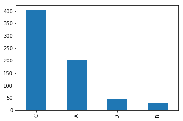

```python
#The status column is our label
df_new['status'].value_counts().plot(kind= 'bar')
```

```python
#we will change to numeric data 0 & 1 and combine A & C, and B & D
df_new['status']
```

```
0      A
1      B
2      A
3      D
4      C
      ..
677    C
678    C
679    C
680    A
681    A
Name: status, Length: 682, dtype: object
```

```python
#Grouping B & D into bad-loans
#Grouping A & C into good-loans

for x in df_new['status'].index:
    status = df_new['status'].loc[x]

    if status == 'A':
        df_new['status'].loc[x] = 0 #good loans as 0
    elif status == 'C':
        df_new['status'].loc[x] = 0 #good loans as 0
    elif status == 'B':
        df_new['status'].loc[x] = 1 #good loans as 1
    elif status == 'D':
        df_new['status'].loc[x] = 1 #good loans as 1
```

```python
df_new['status'] = df_new['status'].astype(int)  #change from string to int
```

```python
#Get loan year and month
df_new['loan_year'] = df_new['loan_date'].dt.year
df_new['loan_month'] = df_new['loan_date'].dt.month

#Get date of account creation as year and month
df_new['account_creation_year'] = df_new['date_of_account_creation'].dt.year
df_new['account_creation_month'] = df_new['date_of_account_creation'].dt.month

#Convert birthdate into a age number
df_new['age'] = 2020 - df_new['birth_date'].dt.year
```

```python
#drop datetime64 object for loan date
#drop datetime64 object for that
#drop birth date
df_new = df_new.drop(columns=['birth_date', 'date_of_account_creation', 'loan_date'])
```

```python
#now we have no object Dtypes except the gender which will be one hot encoded below
#after all have been converted, we can use it for scikit learn finally
df_new.info()
```

```
<class 'pandas.core.frame.DataFrame'>
RangeIndex: 682 entries, 0 to 681
Data columns (total 35 columns):
 #   Column                          Non-Null Count  Dtype
---  ------                          --------------  -----
 0   loan_id                         682 non-null    int64
 1   account_id                      682 non-null    int64
 2   loan_amount                     682 non-null    int64
 3   duration_in_months              682 non-null    int64
 4   payments                        682 non-null    float64
 5   status                          682 non-null    int64
 6   district_id                     682 non-null    int64
 7   disp_id                         682 non-null    int64
 8   client_id                       682 non-null    int64
 9   gender                          682 non-null    object
```

[output cut: 27 more lines]

```python
#all my features
X = df_new.drop(columns=['status'])
```

```python
#my label
y = df_new['status'] # a series of 0 and 1, 0 for good loan, 1 for bad
```

```python
#Only gender is left as an object and it is categorical -> One Hot Encode

X = pd.get_dummies(X, drop_first = True) #only one object type is left which is gender
```

```python
X.columns #looks like gender column was one hot encoded
```

```
Index(['loan_id', 'account_id', 'loan_amount', 'duration_in_months',
       'payments', 'district_id', 'disp_id', 'client_id', 'A4', 'A5', 'A6',
       'A7', 'A8', 'A9', '#_of_urban_inhabitants', 'average_salary', 'A12',
       'A13', 'A14', 'A15', 'A16', 'sum_of_credits_before_loan',
       'sum_of_withdrawals_before_loan', 'MIN_balance_before_loan',
       'MAX_balance_before_loan', 'num_times_balance_below_100',
       'avg_balance_30days_before_loan', 'avg_amount_before_loan', 'loan_year',
       'loan_month', 'account_creation_year', 'account_creation_month', 'age',
       'gender_Male'],
      dtype='object')
```

```python
X['gender_Male'] #one hot encoded
```

```
0      1
1      0
2      1
3      1
4      0
      ..
677    0
678    0
679    0
680    1
681    0
Name: gender_Male, Length: 682, dtype: uint8
```

```python
X.shape
```

```
(682, 34)
```

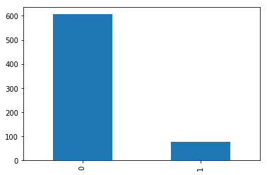

```python
#we can see clearly that the data is imbalanced
y.value_counts().plot(kind = 'bar')
```

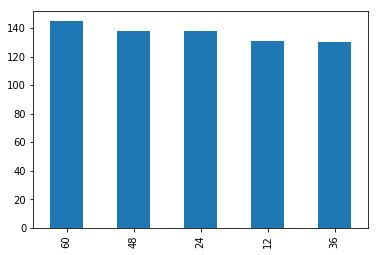

```python
#visualizing loan duration

df_new['duration_in_months'].value_counts().plot(kind = 'bar')
```

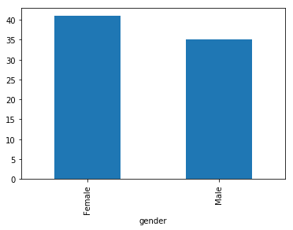

```python
#visualizing gender and default # of defaults

df_new.groupby(['gender'])['status'].sum().plot(kind='bar')
```

```python
df_new.corr().style.background_gradient(cmap='coolwarm')
```

|  | loan_id | account_id | loan_amount | duration_in_months | payments | status | district_id | disp_id | client_id | A4 | A5 | A6 | A7 | A8 | A9 | #_of_urban_inhabitants | average_salary | A12 | A13 | A14 | A15 | A16 | sum_of_credits_before_loan | sum_of_withdrawals_before_loan | MIN_balance_before_loan | MAX_balance_before_loan | num_times_balance_below_100 | avg_balance_30days_before_loan | avg_amount_before_loan | … |
| --- | --- | --- | --- | --- | --- | --- | --- | --- | --- | --- | --- | --- | --- | --- | --- | --- | --- | --- | --- | --- | --- | --- | --- | --- | --- | --- | --- | --- | --- | --- |
| loan_id | 1.000000 | 0.999860 | -0.042968 | 0.010287 | -0.056171 | -0.077255 | -0.055543 | 0.999879 | 0.999642 | 0.095276 | -0.036932 | -0.035496 | -0.043323 | -0.035709 | -0.019717 | 0.070938 | 0.089977 | -0.083069 | -0.089986 | 0.121073 | 0.097068 | 0.096803 | 0.008770 | 0.008770 | -0.005190 | -0.001737 | -0.051389 | 0.038441 | -0.000009 | … |
| account_id | 0.999860 | 1.000000 | -0.043268 | 0.009986 | -0.056067 | -0.078223 | -0.055304 | 0.999984 | 0.999890 | 0.096270 | -0.037720 | -0.035671 | -0.042779 | -0.035559 | -0.019360 | 0.071339 | 0.090687 | -0.083469 | -0.090299 | 0.121259 | 0.098002 | 0.097754 | 0.008970 | 0.008970 | -0.005948 | -0.002176 | -0.051182 | 0.037536 | -0.000725 | … |
| loan_amount | -0.042968 | -0.043268 | 1.000000 | 0.612402 | 0.689481 | 0.167525 | 0.004008 | -0.043180 | -0.043117 | 0.012496 | 0.030037 | 0.010640 | -0.013236 | -0.018481 | -0.012666 | -0.018040 | -0.017310 | -0.063805 | -0.033702 | 0.021436 | 0.010642 | 0.010426 | 0.163113 | 0.163113 | -0.089523 | 0.199768 | 0.128644 | 0.016920 | 0.237498 | … |
| duration_in_months | 0.010287 | 0.009986 | 0.612402 | 1.000000 | -0.040189 | 0.025823 | 0.034391 | 0.010143 | 0.009614 | -0.053727 | 0.040213 | 0.048485 | 0.049668 | -0.028767 | 0.064988 | -0.050838 | -0.073310 | -0.037597 | -0.034325 | -0.005526 | -0.057276 | -0.056786 | -0.051158 | -0.051158 | 0.019120 | -0.057230 | 0.041716 | -0.102749 | -0.063055 | … |
| payments | -0.056171 | -0.056067 | 0.689481 | -0.040189 | 1.000000 | 0.182440 | -0.007029 | -0.056192 | -0.055249 | 0.029347 | 0.029546 | -0.033143 | -0.056942 | 0.027876 | -0.049541 | 0.008382 | 0.019133 | -0.025288 | 0.011079 | 0.000825 | 0.029751 | 0.029344 | 0.253244 | 0.253244 | -0.101514 | 0.310266 | 0.094649 | 0.101528 | 0.368195 | … |
| status | -0.077255 | -0.078223 | 0.167525 | 0.025823 | 0.182440 | 1.000000 | 0.020512 | -0.078001 | -0.078783 | -0.026483 | 0.004688 | -0.020196 | -0.042940 | -0.013263 | -0.037178 | 0.000419 | -0.034555 | 0.006011 | 0.018071 | -0.046420 | -0.027208 | -0.027963 | -0.056840 | -0.056840 | -0.261244 | 0.012065 | 0.367877 | -0.255859 | -0.007210 | … |
| district_id | -0.055543 | -0.055304 | 0.004008 | 0.034391 | -0.007029 | 0.020512 | 1.000000 | -0.055665 | -0.054649 | -0.431556 | -0.038676 | 0.402191 | 0.434025 | 0.409262 | 0.264440 | -0.157338 | -0.445470 | 0.512678 | 0.566524 | -0.647498 | -0.488203 | -0.498458 | -0.000375 | -0.000375 | -0.056617 | -0.002871 | 0.091403 | -0.007764 | -0.012839 | … |
| disp_id | 0.999879 | 0.999984 | -0.043180 | 0.010143 | -0.056192 | -0.078001 | -0.055665 | 1.000000 | 0.999799 | 0.096382 | -0.037609 | -0.035740 | -0.043200 | -0.035848 | -0.019632 | 0.071348 | 0.090771 | -0.083345 | -0.090244 | 0.121437 | 0.098158 | 0.097910 | 0.008854 | 0.008854 | -0.006027 | -0.001977 | -0.051246 | 0.037833 | -0.000237 | … |
| client_id | 0.999642 | 0.999890 | -0.043117 | 0.009614 | -0.055249 | -0.078783 | -0.054649 | 0.999799 | 1.000000 | 0.096069 | -0.037864 | -0.035610 | -0.041759 | -0.034930 | -0.018553 | 0.071389 | 0.090416 | -0.083490 | -0.090304 | 0.120487 | 0.097711 | 0.097467 | 0.009583 | 0.009583 | -0.005855 | -0.002597 | -0.051051 | 0.036769 | -0.001658 | … |
| A4 | 0.095276 | 0.096270 | 0.012496 | -0.053727 | 0.029347 | -0.026483 | -0.431556 | 0.096382 | 0.096069 | 1.000000 | -0.535887 | -0.547405 | -0.457504 | -0.183187 | -0.614363 | 0.697678 | 0.910474 | -0.464142 | -0.507780 | 0.702264 | 0.995781 | 0.994392 | -0.028608 | -0.028608 | 0.006402 | 0.012054 | -0.030977 | 0.015200 | 0.020917 | … |
| A5 | -0.036932 | -0.037720 | 0.030037 | 0.040213 | 0.029546 | 0.004688 | -0.038676 | -0.037609 | -0.037864 | -0.535887 | 1.000000 | 0.442206 | 0.116068 | -0.101561 | 0.386517 | -0.627935 | -0.589766 | 0.064779 | 0.035568 | -0.306661 | -0.513578 | -0.504415 | 0.078316 | 0.078316 | -0.021164 | 0.035083 | -0.035784 | 0.019105 | 0.028486 | … |
| A6 | -0.035496 | -0.035671 | 0.010640 | 0.048485 | -0.033143 | -0.020196 | 0.402191 | -0.035740 | -0.035610 | -0.547405 | 0.442206 | 1.000000 | 0.696636 | 0.123543 | 0.596714 | -0.755772 | -0.624052 | 0.156679 | 0.141305 | -0.360466 | -0.564802 | -0.558126 | 0.012525 | 0.012525 | -0.010191 | -0.010623 | -0.044224 | 0.056030 | -0.024827 | … |
| A7 | -0.043323 | -0.042779 | -0.013236 | 0.049668 | -0.056942 | -0.042940 | 0.434025 | -0.043200 | -0.041759 | -0.457504 | 0.116068 | 0.696636 | 1.000000 | 0.159664 | 0.679394 | -0.552185 | -0.455545 | 0.163366 | 0.170577 | -0.411019 | -0.494042 | -0.490131 | 0.014666 | 0.014666 | 0.005624 | -0.020881 | -0.010948 | 0.035160 | -0.038286 | … |
| A8 | -0.035709 | -0.035559 | -0.018481 | -0.028767 | 0.027876 | -0.013263 | 0.409262 | -0.035848 | -0.034930 | -0.183187 | -0.101561 | 0.123543 | 0.159664 | 1.000000 | 0.313338 | 0.087511 | -0.166631 | 0.564463 | 0.549128 | -0.474285 | -0.219547 | -0.223223 | 0.016434 | 0.016434 | -0.033335 | 0.058745 | 0.123730 | 0.028707 | 0.012590 | … |
| A9 | -0.019717 | -0.019360 | -0.012666 | 0.064988 | -0.049541 | -0.037178 | 0.264440 | -0.019632 | -0.018553 | -0.614363 | 0.386517 | 0.596714 | 0.679394 | 0.313338 | 1.000000 | -0.460808 | -0.598698 | 0.214375 | 0.198670 | -0.418806 | -0.626057 | -0.620097 | 0.028859 | 0.028859 | -0.035141 | 0.004425 | 0.018034 | 0.008023 | -0.039412 | … |
| #_of_urban_inhabitants | 0.070938 | 0.071339 | -0.018040 | -0.050838 | 0.008382 | 0.000419 | -0.157338 | 0.071348 | 0.071389 | 0.697678 | -0.627935 | -0.755772 | -0.552185 | 0.087511 | -0.460808 | 1.000000 | 0.780752 | -0.113040 | -0.157874 | 0.396754 | 0.678266 | 0.664736 | -0.048221 | -0.048221 | -0.020647 | -0.001204 | 0.031250 | -0.040899 | -0.003783 | … |
| average_salary | 0.089977 | 0.090687 | -0.017310 | -0.073310 | 0.019133 | -0.034555 | -0.445470 | 0.090771 | 0.090416 | 0.910474 | -0.589766 | -0.624052 | -0.455545 | -0.166631 | -0.598698 | 0.780752 | 1.000000 | -0.368451 | -0.427481 | 0.646734 | 0.905648 | 0.900038 | -0.031161 | -0.031161 | 0.016426 | 0.015605 | -0.014543 | -0.000717 | 0.032008 | … |
| A12 | -0.083069 | -0.083469 | -0.063805 | -0.037597 | -0.025288 | 0.006011 | 0.512678 | -0.083345 | -0.083490 | -0.464142 | 0.064779 | 0.156679 | 0.163366 | 0.564463 | 0.214375 | -0.113040 | -0.368451 | 1.000000 | 0.931699 | -0.720852 | -0.481169 | -0.486869 | 0.008205 | 0.008205 | -0.020170 | 0.015568 | 0.093436 | -0.029479 | -0.021118 | … |
| A13 | -0.089986 | -0.090299 | -0.033702 | -0.034325 | 0.011079 | 0.018071 | 0.566524 | -0.090244 | -0.090304 | -0.507780 | 0.035568 | 0.141305 | 0.170577 | 0.549128 | 0.198670 | -0.157874 | -0.427481 | 0.931699 | 1.000000 | -0.725351 | -0.521615 | -0.524707 | 0.028630 | 0.028630 | -0.034896 | 0.036842 | 0.129677 | -0.009430 | 0.014501 | … |
| A14 | 0.121073 | 0.121259 | 0.021436 | -0.005526 | 0.000825 | -0.046420 | -0.647498 | 0.121437 | 0.120487 | 0.702264 | -0.306661 | -0.360466 | -0.411019 | -0.474285 | -0.418806 | 0.396754 | 0.646734 | -0.720852 | -0.725351 | 1.000000 | 0.725091 | 0.728005 | -0.029993 | -0.029993 | 0.027900 | -0.009783 | -0.102222 | 0.019946 | -0.001106 | … |
| A15 | 0.097068 | 0.098002 | 0.010642 | -0.057276 | 0.029751 | -0.027208 | -0.488203 | 0.098158 | 0.097711 | 0.995781 | -0.513578 | -0.564802 | -0.494042 | -0.219547 | -0.626057 | 0.678266 | 0.905648 | -0.481169 | -0.521615 | 0.725091 | 1.000000 | 0.999638 | -0.028592 | -0.028592 | 0.009314 | 0.011940 | -0.038200 | 0.015590 | 0.023851 | … |
| A16 | 0.096803 | 0.097754 | 0.010426 | -0.056786 | 0.029344 | -0.027963 | -0.498458 | 0.097910 | 0.097467 | 0.994392 | -0.504415 | -0.558126 | -0.490131 | -0.223223 | -0.620097 | 0.664736 | 0.900038 | -0.486869 | -0.524707 | 0.728005 | 0.999638 | 1.000000 | -0.028023 | -0.028023 | 0.010128 | 0.011699 | -0.038760 | 0.016832 | 0.023530 | … |
| sum_of_credits_before_loan | 0.008770 | 0.008970 | 0.163113 | -0.051158 | 0.253244 | -0.056840 | -0.000375 | 0.008854 | 0.009583 | -0.028608 | 0.078316 | 0.012525 | 0.014666 | 0.016434 | 0.028859 | -0.048221 | -0.031161 | 0.008205 | 0.028630 | -0.029993 | -0.028592 | -0.028023 | 1.000000 | 1.000000 | -0.003639 | 0.714526 | 0.018703 | 0.371679 | 0.470033 | … |
| sum_of_withdrawals_before_loan | 0.008770 | 0.008970 | 0.163113 | -0.051158 | 0.253244 | -0.056840 | -0.000375 | 0.008854 | 0.009583 | -0.028608 | 0.078316 | 0.012525 | 0.014666 | 0.016434 | 0.028859 | -0.048221 | -0.031161 | 0.008205 | 0.028630 | -0.029993 | -0.028592 | -0.028023 | 1.000000 | 1.000000 | -0.003639 | 0.714526 | 0.018703 | 0.371679 | 0.470033 | … |
| MIN_balance_before_loan | -0.005190 | -0.005948 | -0.089523 | 0.019120 | -0.101514 | -0.261244 | -0.056617 | -0.006027 | -0.005855 | 0.006402 | -0.021164 | -0.010191 | 0.005624 | -0.033335 | -0.035141 | -0.020647 | 0.016426 | -0.020170 | -0.034896 | 0.027900 | 0.009314 | 0.010128 | -0.003639 | -0.003639 | 1.000000 | -0.029053 | -0.485742 | 0.050628 | -0.035595 | … |
| MAX_balance_before_loan | -0.001737 | -0.002176 | 0.199768 | -0.057230 | 0.310266 | 0.012065 | -0.002871 | -0.001977 | -0.002597 | 0.012054 | 0.035083 | -0.010623 | -0.020881 | 0.058745 | 0.004425 | -0.001204 | 0.015605 | 0.015568 | 0.036842 | -0.009783 | 0.011940 | 0.011699 | 0.714526 | 0.714526 | -0.029053 | 1.000000 | 0.008331 | 0.464088 | 0.741390 | … |
| num_times_balance_below_100 | -0.051389 | -0.051182 | 0.128644 | 0.041716 | 0.094649 | 0.367877 | 0.091403 | -0.051246 | -0.051051 | -0.030977 | -0.035784 | -0.044224 | -0.010948 | 0.123730 | 0.018034 | 0.031250 | -0.014543 | 0.093436 | 0.129677 | -0.102222 | -0.038200 | -0.038760 | 0.018703 | 0.018703 | -0.485742 | 0.008331 | 1.000000 | -0.183981 | -0.051544 | … |
| avg_balance_30days_before_loan | 0.038441 | 0.037536 | 0.016920 | -0.102749 | 0.101528 | -0.255859 | -0.007764 | 0.037833 | 0.036769 | 0.015200 | 0.019105 | 0.056030 | 0.035160 | 0.028707 | 0.008023 | -0.040899 | -0.000717 | -0.029479 | -0.009430 | 0.019946 | 0.015590 | 0.016832 | 0.371679 | 0.371679 | 0.050628 | 0.464088 | -0.183981 | 1.000000 | 0.539906 | … |
| avg_amount_before_loan | -0.000009 | -0.000725 | 0.237498 | -0.063055 | 0.368195 | -0.007210 | -0.012839 | -0.000237 | -0.001658 | 0.020917 | 0.028486 | -0.024827 | -0.038286 | 0.012590 | -0.039412 | -0.003783 | 0.032008 | -0.021118 | 0.014501 | -0.001106 | 0.023851 | 0.023530 | 0.470033 | 0.470033 | -0.035595 | 0.741390 | -0.051544 | 0.539906 | 1.000000 | … |
| loan_year | -0.070573 | -0.069607 | 0.073150 | 0.088973 | 0.000032 | -0.113935 | 0.027262 | -0.069620 | -0.069670 | -0.063945 | 0.040571 | 0.015664 | 0.057676 | 0.094672 | 0.086935 | -0.045106 | -0.087080 | 0.031819 | 0.050330 | -0.088836 | -0.067905 | -0.067198 | 0.116371 | 0.116371 | 0.013345 | 0.019820 | 0.008345 | 0.017769 | -0.011713 | … |
| loan_month | -0.004675 | -0.004458 | 0.034022 | -0.016661 | 0.028602 | -0.030441 | 0.061718 | -0.004296 | -0.004659 | -0.017626 | -0.030276 | 0.042872 | 0.040089 | -0.032953 | -0.018433 | -0.024047 | -0.022123 | -0.025605 | -0.007850 | -0.005766 | -0.022044 | -0.023179 | 0.053650 | 0.053650 | -0.034901 | 0.053886 | 0.005527 | 0.114065 | 0.064112 | … |
| account_creation_year | -0.054081 | -0.052881 | 0.053815 | 0.058506 | -0.000867 | -0.113800 | 0.034334 | -0.052866 | -0.053044 | -0.046448 | -0.001940 | 0.002038 | 0.057064 | 0.095604 | 0.064689 | -0.021704 | -0.064574 | 0.022978 | 0.041518 | -0.077795 | -0.052886 | -0.052841 | -0.062576 | -0.062576 | 0.010810 | -0.020148 | -0.011211 | 0.051930 | 0.059869 | … |
| account_creation_month | -0.004684 | -0.005241 | 0.049925 | 0.087120 | -0.011026 | 0.067802 | 0.038930 | -0.005138 | -0.005423 | -0.043714 | 0.052550 | 0.077873 | 0.049597 | -0.046289 | 0.033801 | -0.073808 | -0.051413 | 0.020463 | 0.026045 | -0.024376 | -0.040929 | -0.040081 | -0.005617 | -0.005617 | 0.013650 | -0.037352 | -0.020514 | -0.004892 | -0.012220 | … |
| age | -0.119167 | -0.118945 | -0.072379 | -0.042637 | -0.031603 | 0.011931 | 0.014708 | -0.119374 | -0.117911 | -0.055232 | 0.070879 | 0.006412 | 0.034082 | 0.020088 | 0.059642 | -0.020562 | -0.056718 | 0.061517 | 0.049639 | -0.063664 | -0.054846 | -0.055326 | -0.075973 | -0.075973 | 0.067861 | -0.022847 | 0.012859 | -0.051172 | -0.002683 | … |

## Begin of Machine Learning

```python
from sklearn.datasets import make_blobs
from sklearn.datasets import make_moons
from sklearn.tree import DecisionTreeClassifier
from sklearn.linear_model import LogisticRegression
from sklearn.neighbors import KNeighborsClassifier
from sklearn.ensemble import RandomForestClassifier
from sklearn.svm import SVC
from sklearn.model_selection import train_test_split
from sklearn.datasets import load_breast_cancer
from sklearn.metrics import classification_report
from sklearn.metrics import confusion_matrix
from sklearn.metrics import precision_score, recall_score, accuracy_score
from imblearn.over_sampling import SMOTE
from sklearn.model_selection import KFold
from sklearn.metrics import f1_score
```

## Random Forest Model

```python
#need to stratify because data is imbalanced
#the split needs to be done BEFORE you over sample
X_train, X_test, y_train, y_test = train_test_split(X, y, stratify=y, test_size=0.3, random_state=42)
```

```python
#smote to take care of the noise being magnified
smote = SMOTE(random_state=42)
XOverSampled, yOverSampled = smote.fit_resample(X_train,y_train) #resampling only the training set
```

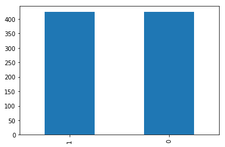

```python
#over sampled
yOverSampled.value_counts().plot(kind = 'bar')
```

```python
model = RandomForestClassifier(n_estimators= 300, max_depth = 10, random_state=42)

model.fit(XOverSampled, yOverSampled)

y_pred_train = model.predict(XOverSampled)
y_pred = model.predict(X_test)
```

```python
#looks correct, resampling only the training set
yOverSampled.value_counts()
```

```
1    424
0    424
Name: status, dtype: int64
```

```python
#looks correct, resampling only the training set
y_test.value_counts()
```

```
0    182
1     23
Name: status, dtype: int64
```

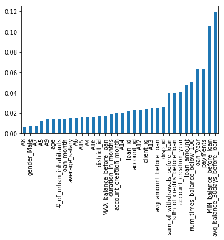

```python
#visualizing the most imoprtant features for our model
pd.Series(model.feature_importances_, index=X.columns).sort_values().plot(kind='bar');
```

## Which metric to use

- **Recall**: from the actual defaults, how many did you capture correctly
- **Precision**: from the predicted defaults, how many were actually correct

Recall would be important to the bank to make sure that they don't lose money. You want to correctly capture the loans that will default.

Tuning down the max_depth will allow you to obtain a higher recall at the cost of precision

I can quite easily improve my precision by maximizing max_depth, however this would be at the cost of a lower recall

```python
print(classification_report(y_test, y_pred))
```

```
              precision    recall  f1-score   support

           0       0.95      0.97      0.96       182
           1       0.72      0.57      0.63        23

    accuracy                           0.93       205
   macro avg       0.83      0.77      0.80       205
weighted avg       0.92      0.93      0.92       205
```

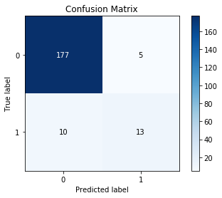

```python
import scikitplot as skplt
skplt.metrics.plot_confusion_matrix(y_test, y_pred)
```